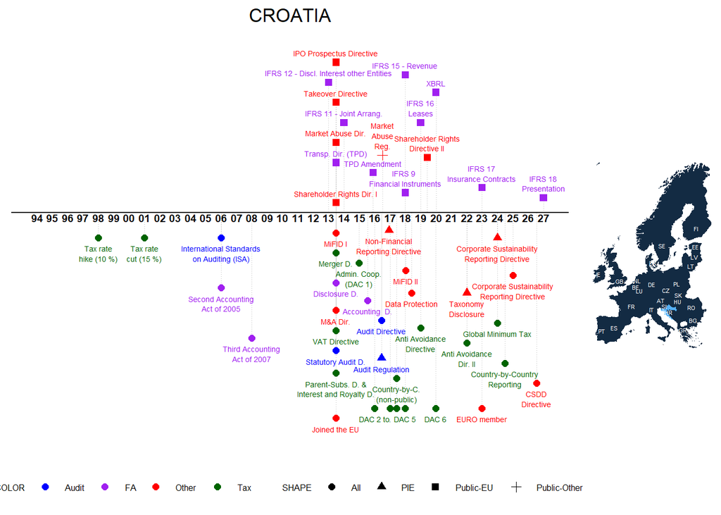

Notes: The graph depicts major regulatory changes that we identified via an extensive literature search, an online survey of mentioned authors, and other sources. Please note that the graph does not include all possible regulatory changes, e.g. minor revisions to local GAAP or tax rate changes below 3% are not included. The dates of EU Directives are based on the official transposition deadlines unless denoted with a *, in which case we included the entry-to-force date as identified in the literature. For more information, please go to [Labro and Pierk (2023)](http://www.eu-regulations.com/Labro_Pierk_2023.pdf). We kindly ask that you cite the paper if you use the information on this website in your research project. Do you have comments or see anything missing? Please email us!

## Regulations, Publications, Further Graphs

The tab ‘Regulations’ includes links to the regulations, gives short descriptions, and provides selective papers for further reading. If the regulation is a national transposition of an EU Directive, the link to the Directive is given. The tab ‘Number of Regulations’ shows graphically the number of regulations 8 years around the respective year (-4,-3,-2,-1,0,+1,+2,+3). The tab ‘Number of Categories” shows graphically the number of different categories 8 years around the respective year (-4,-3,-2,-1,0,+1,+2,+3). The tab ’Publications’ shows all publications that include the countries’ names and variations thereof in the title, abstract, or keywords. Similarly, the tab ‘SSRN’ shows papers of the SSRN Accouning Research Network that include the countries’ names and variations.

### Regulations

|  | Date | Milestones | Applies_to | Category | Description |
| --- | --- | --- | --- | --- | --- |
| 1 | 1998-01-01 | Tax rate hike (10 %) | All Firms | Tax | Tax rate increase (10 %): Croatia increased the corporate tax rate by 10 percentage points (from 25 to 35 percent). |
| 2 | 2001-01-01 | Tax rate cut (15 %) | All Firms | Tax | Tax rate cut (15 %): Croatia reduced the corporate tax rate by 15 percentage points (from 35 to 20 percent). |
| 3 | 2006-01-01 | Second Accounting Act of 2005 | All Firms | FA | Zakon o računovodstvu no. 146 (2005) (Accounting Act, Official Gazette of the Republic of Croatia, no. 146 (2005).): The first Accounting Act of 1991 required all firms to use the International Accoun… |
| 4 | 2006-01-01 | International Standards on Auditing (ISA) | All Firms | Audit | ISA mandatory: The International Standards on Auditing (ISA) became mandatory. See also: Rykaczewski, Thevenot, and Vulcheva 2022 |
| 5 | 2008-01-01 | Third Accounting Act of 2007 | All Firms | FA | Zakon o računovodstvu no. 109 (2007) (Accounting Act, Official Gazette of the Republic of Croatia, no. 109 (2007).): Small and medium-sized entities can only use CFRS, the option to use the Internatio… |
| 6 | 2008-01-01 | VAT Directive | All Firms | Tax | National transposition into several laws: The Directive states that the standard rate of the value-added tax (VAT) may not be lower than 15% and a maximum of two reduced rates not lower than 5%. The D… |
| 7 | 2012-01-18 | Parent-Subsidiary Directive | All Firms | Tax | National transposition into several laws: Abolished withholding taxes on dividend distributions paid by subsidiary companies to their parent company within the EU. National transposition of Directive … |
| 8 | 2013-07-01 | VAT Directive | All Firms | Tax | National transposition into several laws: The Directive states that the standard rate of the value-added tax (VAT) may not be lower than 15% and a maximum of two reduced rates not lower than 5%. The D… |
| 9 | 2013-07-01 | Parent-Subsidiary Directive | All Firms | Tax | Member State does not consider the transposition necessary.: Abolished withholding taxes on dividend distributions paid by subsidiary companies to their parent company within the EU. National transpos… |
| 10 | 2013-07-01 | IFRS Regulation | Public-EU | FA | Regulation 1606/2002: Firms listed on EU-regulated markets are required to use the International Financial Reporting Standards (IFRS) for their consolidated financial statements. Firms that use US GAA… |

[output cut: 46 more lines]

### Number of Regulations

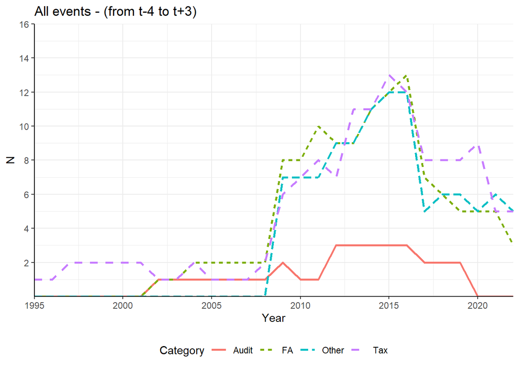

### Number of Categories

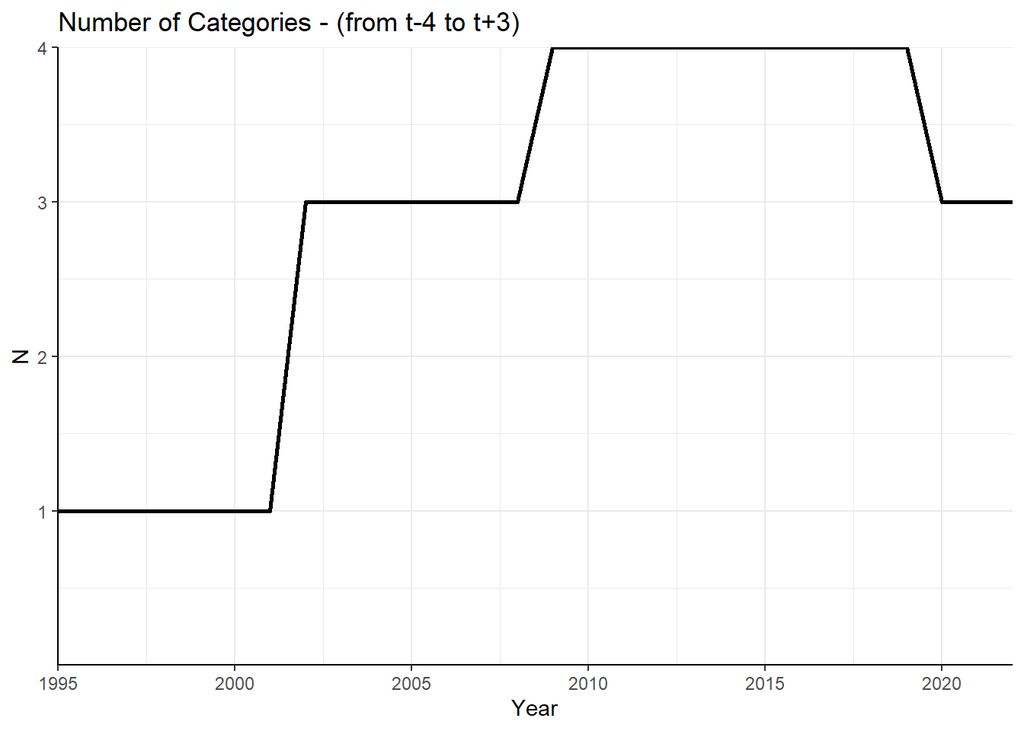

### Publications

|  | authors | title | year | journal |
| --- | --- | --- | --- | --- |
| 1 | Šodan S., Aljinović Barać Ž. | the role and current status of ifrs in the completion of national accounting rules–evidence from croatia | 2017 | Accounting in Europe |
| 2 | Alissa W., Capkun V., Jeanjean T., Suca N. | an empirical investigation of the impact of audit and auditor characteristics on auditor performance | 2014 | Accounting, Organizations and Society |
| 3 | Spremic M., Strugar I. | strategic is planning practise in croatia: organizational and managerial challenges | 2002 | International Journal of Accounting Information Systems |

### SSRN

|  | authors | title | Posted | Revised |
| --- | --- | --- | --- | --- |
| 1 | Bojan Tomić | ispitivanje teorije hijerarhije financijskih izbora na hrvatskom tržištu kapitala (the existence of the pecking order theory of capital structure on croatian capital market) | 2020-07-15 |  |